# TimiRGeN : Time series miR-mRNA integration and Generation of Networks

Krutik Patel

# 1 : Introduction

Time incorporating microRNA Generation of Networks (TimiRGeN) is aimed at researchers who wish to explore time series microRNA-mRNA data. This package integrates, functionally analyses and generates small networks which can help to generate hypothesis.

There are many microRNA (miR) and mRNA data integration and analysis packages, however they tend to only be capable of a few tasks necessary for analysing this type of data. An important outcome which many of these tools do not achieve is reduction of the volume of data. The pipeline of this package takes inspiration from many of the previously published miR-mRNA integration tools to perform a more complete task. Furthermore, this package is made to deal with time series miR-mRNA data which is a growing resource in biology.

To achieve data reduction without reducing biological signal, the TimiRGeN package utilises several published packages and employs their functions in a synergistic fashion for time series multi-omic analysis. The following packages have been built upon for several functions in the TimiRGeN package:

rWikiPathways [1], clusterProfiler [2], [DOSE](https://bioconductor.org/packages/release/bioc/html/DOSE.html) [3], [biomaRt](https://bioconductor.org/packages/release/bioc/html/biomaRt.html) [4], [RCy3](https://bioconductor.org/packages/release/bioc/html/RCy3.html) [5], [Mfuzz](https://www.bioconductor.org/packages/release/bioc/html/Mfuzz.html) [6], [igraph](https://igraph.org/redirect.html) [7].

The pipeline which the TimiRGeN package is based on aims to reduce the volume of data found in time series multi-omic data sets from potentially millions of possible miR-mRNA interactions to a handful. The following miR target databases are used to achieve this:

[TargetScans](http://www.targetscan.org/vert_72/)[8]. [miRDB](http://www.mirdb.org/)[9]. [miRTarBase](http://mirtarbase.mbc.nctu.edu.tw/php/index.php)[10].

The output will be applicable for gene regulatory network (GRN) generation, and in turn will be a foundation for further work such as: mathematical modelling, bioinformatics exploration, a literature search and/ or help as a resource for experimental design.

TimiRGeN does have some capability to generate networks in R, however this package is uniquely open ended, as the output can be easily be exported to [Cytoscape](https://cytoscape.org/) [11] and [Pathvisio](https://pathvisio.github.io/) [12] for better visualisation options.

Furthermore, TimiRGeN solely uses wikipathways for functional pathway analysis, and is the first tool to allow this for time series data. Wikipathways is a user curated pathway database that contains 1000s of mechanistic signalling pathways of multiple species [13]. Furthermore, wikipathways works very well with Pathvisio which is our recommended tool for GRN exploration. Currently TimiRGeN only supports Human and Mouse data.

Overall, this is an all purpose miR-mRNA integration and analysis package. It has been made for time series data but can also accommodate conditional data sets. Furthermore, mRNA data can be run through by itself for functional analysis. Overall, the TimiRGeN package is built upon ideas from many previous miR-mRNA integration and several packages to deliver an open ended, versatile and powerful tool for multi-omic analysis.

# 2 : Install TimiRGeN

```r
if (!requireNamespace("BiocManager", quietly = TRUE)) install.packages("BiocManager")

BiocManager::install("TimiRGeN")
```

# 3 : Load Libraries

```r
libstoinst <- c("dplyr", "gtools", "rWikiPathways", "tidyr",
    "stringr", "tidyverse", "clusterProfiler", "biomaRt", "org.Hs.eg.db",
    "org.Mm.eg.db", "RCy3", "ggplot2", "TimiRGeN", "igraph",
    "Mfuzz", "readxl", "MultiAssayExperiment")

lapply(libstoinst, require, character.only = TRUE)
```

The following dependencies can be investigated further from these sources [1-7, 14-23]

# 4 : Time Series microRNA-mRNA Integrated Analysis

## 4.1 Example Mouse Kidney Fribrosis Dataset

The TimiRGeN package gives the user several options for their analysis. Currently the package can only analyse human and mouse data and can analyse miR and mRNA data combined or separately. In this section the combined method will be used to analyse a mouse kidney fibrosis data set. The mRNA data from [Craciun et al (2016)](https://www.ncbi.nlm.nih.gov/pmc/articles/PMC4884105/) [24] which was downloaded from GSE65267. The associated miR data was published in [Pellegrini et al (2016)](https://www.ncbi.nlm.nih.gov/pmc/articles/PMC4912473/) [25] and was downloaded from GSE61328.

```r
miR <- mm_miR

mRNA <- mm_mRNA
```

Notice the standard nomenclature used in the column names. Do follow the this standard for your own input data. The time point or should come first and is followed by a ‘.’.

After the ‘.’ the string should continue to display the specific result types from differential expression analysis. Note there should only be one ‘.’ in each column name and no ‘-’ characters. Having more than one ‘.’ any ‘-’ characters will confuse some functions.

Note. There should be no NAs in your miR and mRNA data files. Some differential expression tools lead to some NAs appearing. If this is the case please change all NA to 1, or another high number so they are removed during downstream filtration stages of the pipeline.

## 4.2 Create MultiAssayExperiment object

```r
Data <- StartObject(miR = miR, mRNA = mRNA)
```

TimiRGeN employes `MultiAssayExperiment` (MAE) to contain all the data. The data frames, matrices and other S4 objects are stored in `ExperimentList`, and the lists will be stored in the `metadata`.

## 4.3 Retreive Gene IDs

```r
Data <- getIDs_miR_mouse(MAE = Data, miR = Data@ExperimentList$miR)

Data <- getIDs_mRNA_mouse(MAE = Data, mRNA = Data@ExperimentList$mRNA)
```

Using `getIDs` functions the entrez gene and ensembl annotation data for genes can be retrieved for downstream analysis.

Many wikipathways use either entrezgene IDs or ensembl gene IDs for annotation. Having both formats available can be useful. Also, due to the nature of miRs, many NAs may be found in the output. Adjusted outputs can also be found for miR data, because entrez gene IDs and ensemble gene IDs are insensitive to miRs with -3p and -5p strands. Therefore, slightly adjusted entrez gene IDs or ensemble gene IDs to identify if miRs are of the -3p or -5p strand

## 4.4 Filter Out Non-significant Genes

```r
Data@ExperimentList$genetic_data <- CombineGenes(miR_data = Data@ExperimentList$miR,
    mRNA_data = Data@ExperimentList$mRNA)

Data@metadata$genelist <- GenesList(method = "c", genetic_data = Data@ExperimentList$genetic_data,
    timeString = "D")

Data@metadata$filtered_genelist <- SignificantVals(method = "c",
    geneList = Data@metadata$genelist, maxVal = 0.05, stringVal = "adjPVal")
```

mRNA and miR data can be combined using `CombineGenes` function.

The `GenesList` function will transform the large data frame into multiple nested data frames within a list. The data will be separated by time. In this example by ‘D’ (days), because it was before the ‘.’.

Significant genes can be retrieved from each nested data frame using the `SignificantVals` function. Here only genes which had an adjusted P value of less than 0.05 will remain in the list.

### 4.4.1 Find Significant Gene IDs

```r
Data@metadata$gene_entrez <- AddIDs(method = "c", filtered_genelist = Data@metadata$filtered_genelist,
    miR_IDs = Data@ExperimentList$miR_entrez, mRNA_IDs = Data@ExperimentList$mRNA_entrez)

Data@metadata$e_list <- eNames(method = "c", gene_IDs = Data@metadata$gene_entrez,
    ID_Column = 4)
```

Now entrez IDs or ensembl IDs which were created before can be integrated into our filtered data frames of genes using `AddIDs`. For this example entrez gene IDs were be added.

Lists of entrezIDs/ ensembl IDs can be extracted for further analysis using `eNames` function.

## 4.5 Time Dependent Pathway Enrichment Method

Once we have a list of significant genes per time point we can put this through gene set enrichment to find novel pathways which this data is associate with. To do this TimiRGeN uses wikipathways [13].

```r
Data <- dloadGMT(MAE = Data, speciesInitials = "Mm")
```

This is standard GSEA where we look to find which wikipathways are enriched in our data, per time point/ condition. The `EnrichWiki` function wraps around enrichment functions from DOSE and clusterProfiler [2,3] but uses them for time series analysis with wikipathways.

```r
Data@metadata$sigwiki <- EnrichWiki(method = "c", e_list = Data@metadata$e_list,
    orgDB = org.Mm.eg.db, path_gene = Data@ExperimentList$path_gene,
    path_name = Data@ExperimentList$path_name, ID = "ENTREZID",
    universe = Data@ExperimentList$path_gene$gene)
```

`path_gene` and `path_name` can be found as output from the `dloadGMT` function. For a more stringent check, a user can add their own `universe` data e.g. all possible genes in a microarray or all known genes found in a cell type. `"ENSEMBL"` should be used if ensemble gene IDs were added to the `e_list`.

### 4.5.1 Plot GSEA

```r
SavePlots(largeList = Data@metadata$sigwiki, maxInt = 5, quickType = Quickdot,
    fileType = "jpg")
```

To plot the GSEA `Quickbar` or `Quickdot` can be used and the plots can be saved in a variety of different formats.

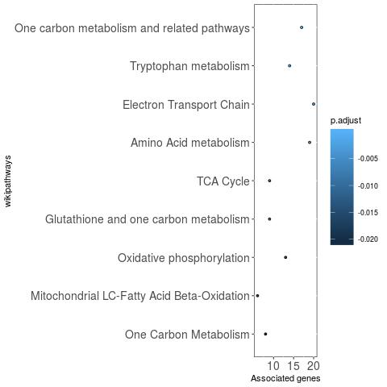

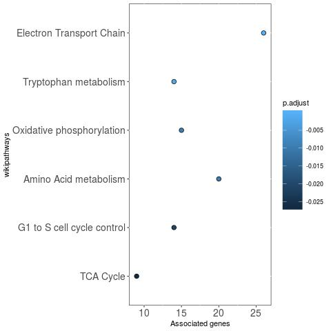

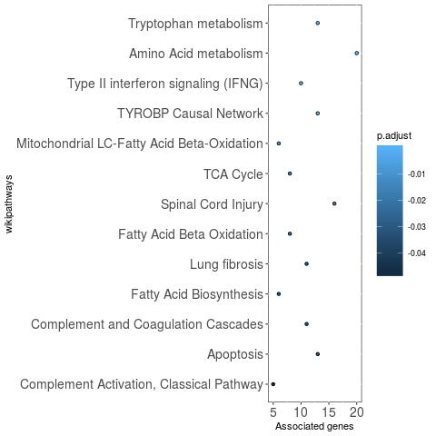

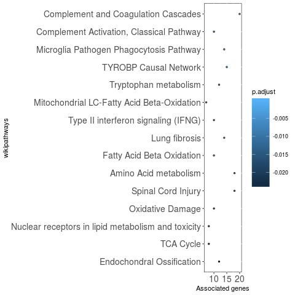

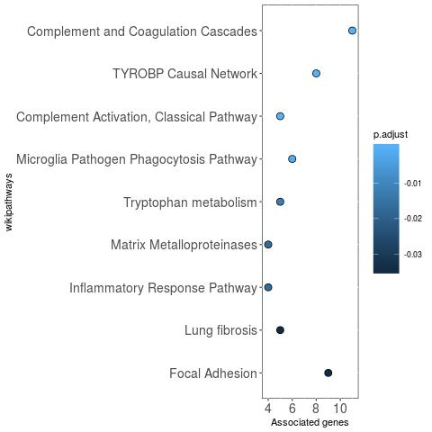

From here a wikipathway can be selected for miR-mRNA interaction analysis. For example the Complement and Coagulation pathway.

## 4.6 Temporal Pathway Clustering Method

TimiRGeN also offers a supervised soft clustering method using Mfuzz. This aims to reduce the amount of possible pathways to look into and direct their investigation. This provides a global view of temporal patterns based on the common genes found between the data at each time point and each wikipathway.

### 4.6.1 Create Percent Matrix

```r
Data@metadata$wlist <- WikiList(stringSpecies = "Mus musculus",
    stringSymbol = "L")
```

This method starts by importing all mouse wikipathways and associated gene IDs, per mouse wikipathway. Would be ‘Homo sapiens’ for human data. The `L` symbol will give us entez gene IDs and the `En` symbol will give ensembl gene IDs.

```r
Data@ExperimentList$Wmat <- WikiMatrix(e_list = Data@metadata$e_list,
    wp_list = Data@metadata$wlist)
```

This Large list of genes and pathways is converted to a Matrix by `WikiMatrix`.

Now each time point from the data is represented by rows and the pathways are represented by columns. A user can see how many genes are common between each pathway, in each time point.

```r
Data@metadata$Pmat <- TurnPercent(wikiMatrix = Data@ExperimentList$Wmat,
    rowInt = 6)
```

The final row is the total number of genes in each pathway. The `rowInt` parameter in the `TurnPercent` function should point to the final row in the `Wmat`. This will account for pathway of differing sizes.

### 4.6.2 Temporal Pathway Clustering

```r
Data <- CreateClusters(MAE = Data, method = "c", Percent_matrix = Data@metadata$Pmat,
    no.clusters = 12, Variance = 0.99)
```

```
## 26 genes excluded.
```

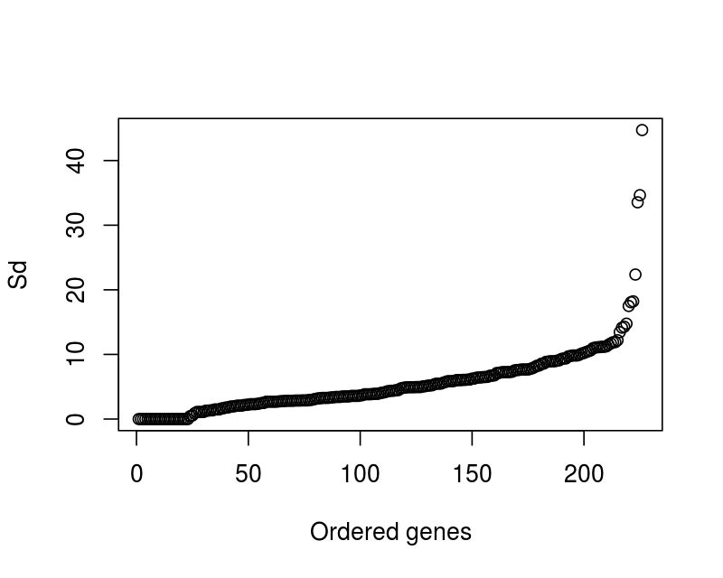

`CreatClusters` uses functions from Mfuzz [6] to separate the percent matrix into a number of clusters based on temporal changes. In our example we created 12 clusters. Please refer to the Mfuzz source material for more information [26].

Note.The message “genes excluded” refers to wikipathways in TimiRGeN.

The standard deviation plot is from Mfuzz, this shows the variance in the data.

There are three output files from `CreateClusters`. `ClusterData` which is a Matrix displaying the respective fits of each pathway to each cluster, and the description for each pathway. `Clusters` which is information needed to create downstream plots. `Mfuzzdata` which again is required to create downstream plots.

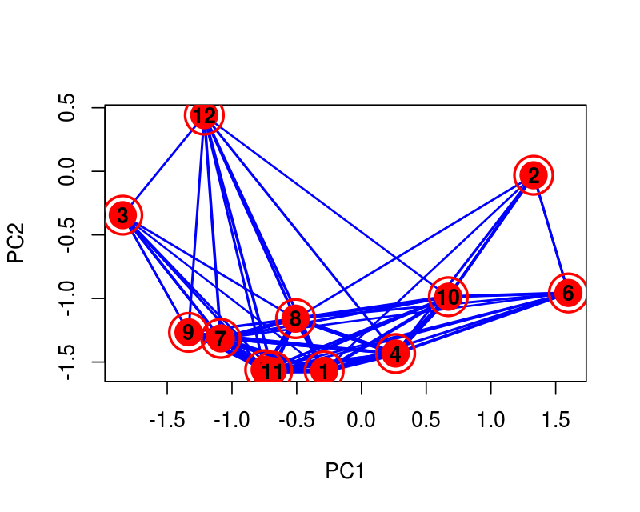

```
##            PC1         PC2        PC3         PC4        PC5
## D1  -0.5696185  0.23832162 -0.2035174  0.60707226 -0.4569261
## D2  -0.4965075 -0.38797103  0.3523893 -0.53013047 -0.4446822
## D3   0.2701301 -0.52213635 -0.7240737 -0.05287252 -0.3568264
## D7   0.5869788  0.01165238  0.4840915  0.26156859 -0.5937655
## D14  0.1072415  0.72105418 -0.2752728 -0.52840450 -0.3370367
```

```r
ClusterCheck(Clusters = Data@metadata$Clusters, W = FALSE)
```

ClusterCheck creates a PCA plot for each of the clusters. The closer the clusters are the more similar they are to one another. We can also see which time points have the most variance from one another.

### 4.6.3 Plot Clusters

Once we are happy about the number of clusters we can plot fuzzy clusters. The Y axis has the normalised number of genes and the X axis has the time points.

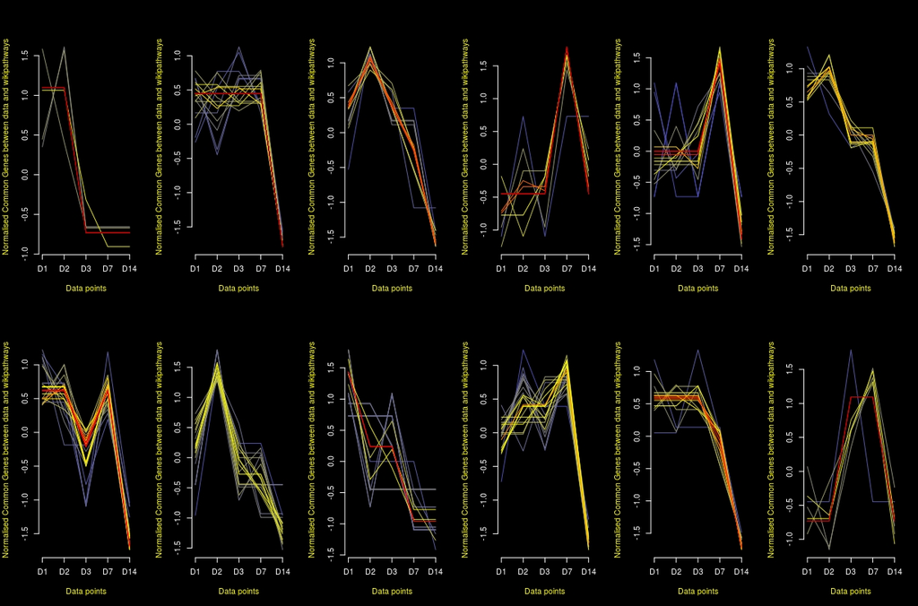

```r
Quickfuzz(Mfuzzdata = Data@ExperimentList$MfuzzData, Clusters = Data@metadata$Clusters,
    W = FALSE)
```

The red lines represent wikipathways that fit very well in a respective cluster.\ The orange lines represent wikipathways that fit well in a respective cluster.\ The yellow lines represent wikipathways that somewhat fit in a respective cluster.\ The purple lines represent wikipathways that partially fit in a respective cluster.\

Note. After using Quickfuzz you may want to clear plots as there could be visual defects if one attempts to create new plots.

### 4.6.4 Examine clusters of interest

```r
Data@ExperimentList$CLUST12_0.9 <- ReturnCluster(ClusterData = Data@ExperimentList$ClusterData,
    which.cluster = 12, fit.cluster = 0.9)
```

Finally we can extract the information of a particular cluster we may be interested in. For example cluster 12 has a nice dynamic where the the number of significantly deferentially expressed genes at time points D3 and D7 peak.

#### 4.6.4.1 Get Pathway Information

```r
getXrefList(pathway = "WP200", "L")
getPathwayInfo("WP200")
```

Once a pathway has been identified for further analysis, rWikipathways [1] function can be used to retrieve information. Please read the rWikipathways documentation for more details.

## 4.7 Take Selected Pathways Forward

```r
Data@ExperimentList$miRNA_log2fc <- Express(df = Data@ExperimentList$miR,
    dataType = "Log2FC", genes_ID = Data@ExperimentList$miR_entrez,
    idColumn = "GENENAME")

Data@ExperimentList$mRNA_log2fc <- Express(df = Data@ExperimentList$mRNA,
    dataType = "Log2FC", genes_ID = Data@ExperimentList$mRNA_entrez,
    idColumn = "GENENAME")
```

The `Express` function will retrieve one specific of the differential expression result type, along with either entrez gene IDs or ensembl gene IDs from a `getIDs` function. It is recommend to use Log2FC or normalised expression values here as these values will be averaged further downstream of the pipeline.

The `idcolumn` refers to which column on the `miR/mRNA_entrez` or `miR/mRNA_ensembl` contains the gene names. If the user has not renamed the columns they should keep this as `GENENAME`.

### 4.7.1 Find Genes in the Pathways of Interest and the Input mRNA Data

```r
Data@ExperimentList$Complement <- ReduceWiki(path_data = Data@ExperimentList$path_data,
    stringWiki = "Complement and Coagulation Cascades")

Data@ExperimentList$GenesofInterest <- WikimRNA(mRNA_express = Data@ExperimentList$mRNA_log2fc,
    SingleWiki = Data@ExperimentList$Complement)
```

A selected wikipathway can be put through `ReduceWiki` to extract the genes which are found in this pathway. The `path_data` comes from the `dloadGMT` function.

Note. Make sure the spelling of the pathway is correct.

`WikimRNA` will find which of the genes from the selected pathway are also found within your input data.

## 4.8 Create Correlation Matrix

```r
Data@ExperimentList$Corr_matrix <- miR_mRNA_IntDF(miR_express = Data@ExperimentList$miRNA_log2fc,
    GenesofInterest = Data@ExperimentList$GenesofInterest, maxInt = 5)
```

`miR_mRNA_IntDF` creates a correlation matrix for every possible miR-mRNA interaction between the GenesofInterest and all the input miRs.

Note. There should be no NA values in the `miRNA_log2fc` data frame.

The `maxInt` parameter must be equal the number of time points your miR and mRNA data have.

## 4.9 Download miR-mRNA Interaction Database Data

TargetScans v7.2, miRDB v6.0 and miRtarBase v7.0 [8-10] can be used to determine which of the potential miR-mRNA interactions have been predicted/ functionally tested. The following code will download the latest versions of the data sets and format them for database mining.

For human analysis use `"hsa"` and `org.Hs.eg.db`.

```r
Data@ExperimentList$TargetScans <- dloadTargetScans()
```

```
## [1] "Downloaded Predicted Targets Context Scores default version 7.2"
## [1] "Check if a newer version is available?"
## [1] "http://www.targetscan.org/vert_72/"
## [1] "If so download that and run it through Targetscans_data function."
```

```r
Data@ExperimentList$TargetScans_res <- TargetScans_data(targetScan = Data@ExperimentList$TargetScans,
    species = "mmu")
```

```r
Data@ExperimentList$miRDB <- dloadmiRDB()
```

```
## [1] "Downloaded Predicted Targets from miRDB version 6.0"
## [1] "Check if a newer version is available? http://mirdb.org/."
## [1] "If so download that and run it through miRDB_data function."
```

```r
Data@ExperimentList$miRDB_res <- miRDB_data(miRDB = Data@ExperimentList$miRDB,
    species = "mmu", orgDB = org.Mm.eg.db)
```

```r
Data@ExperimentList$miRTarBase <- dloadmiRTarBase()
```

```
## [1] "Downloaded published miRNA target interaction data version 7.0"
## [1] "Check if a newer version is available?\nhttp://mirtarbase.mbc.nctu.edu.tw/php/index.php."
## [1] "If so download that and run it through miRTarBase_data function."
```

```r
Data@ExperimentList$miRTarBase_res <- miRTarBase_data(mirtarbase = Data@ExperimentList$miRTarBase,
    species = "mmu")
```

miRTarBase is filled with a number of “functional” miR-mRNA interactions but not all of them have the same degree of experimental scrutiny. Any evidence type that is labelled as “weak”" has been removed so the functionally assessed miR-mRNA interactions can be trusted to a higher degree.

## 4.10 Mine Predicted or Funtionally Assessed miR-mRNA Interactions

```r
Data@ExperimentList$mining_matrix <- DataMiningMatrix(corrTable = Data@ExperimentList$Corr_matrix,
    targetscan = Data@ExperimentList$TargetScans_res, mirdb = Data@ExperimentList$miRDB_res,
    mirtarbase = Data@ExperimentList$miRTarBase_res)
```

The `DataMiningMatrix` will find identify if any of the potential interactions from the `Corr_matrix` are predicted/ functionally assessed, and display this as intergers.

### 4.10.1 Filter Out miR-mRNA Interactions Based on Evidence

```r
Data@ExperimentList$filt_df <- MatrixFilter(miningMatrix = Data@ExperimentList$mining_matrix,
    NegativeOnly = TRUE, THRESHOLD = 2, PredictedOnly = FALSE,
    maxCor = -0.5)
```

Potential interactions with no-little evidence can be filtered out using parameters on `MatrixFilter`.

`NegativeOnly` being TRUE will only filter for interactions with a negative average correlation. `THRESHOLD` being 2 will filter for interactions with two or more databases where the interactions are identified. `PredictedOnly` being TRUE will ignore interactions found on miRTarBase.

## 4.11 Create Internal R Networks

```r
Data@metadata$net <- MakeNet(filt_df = Data@ExperimentList$filt_df)

Quicknet(net = Data@metadata$net)
```

Utilising igraph [7] the filtered miR-mRNA interactions can be displayed. The colour of the edges represents the level of average correlations between the miRs and mRNAs.

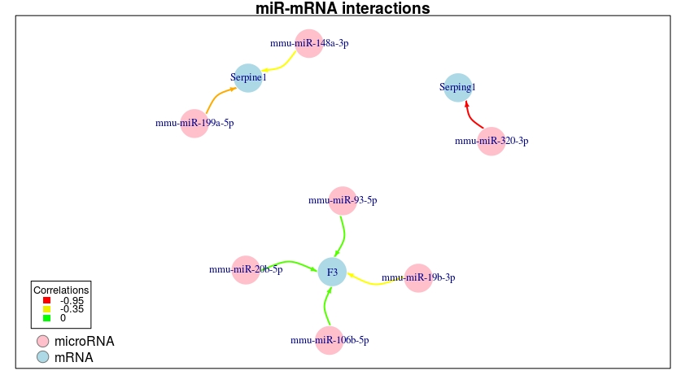

Note. Adjust size of the plot window to access the key in the bottom left hand side.

Note. Having more than 15 interactions will be very difficult to see in R and we recommend exporting to Cytoscape in these cases.

This plot can give an idea on how many interesting miR-mRNA interactions there are in this pathway, given the input data. Based on this a user can continue their bioinformatics investigations by exporting this data to Cytoscape or Pathvisio.

## 4.12 Output for Pathvisio

```r
Data@ExperimentList$Dynamics <- MakeDynamic(miR_expression = Data@ExperimentList$miRNA_log2fc,
    mRNA_expression = Data@ExperimentList$mRNA_log2fc, miR_IDs_adj = Data@ExperimentList$miR_entrez,
    Datatype = "L")

write.csv(Data@ExperimentList$Dynamics, "Dynamics.csv", row.names = TRUE,
    quote = FALSE)

Data@ExperimentList$MAPP <- MakeMapp(filt_df = Data@ExperimentList$filt_df,
    miR_IDs_adj = Data@ExperimentList$miR_entrez, Datatype = "L")

write.table(Data@ExperimentList$MAPP, "MAPP.txt", quote = FALSE,
    row.names = FALSE, col.names = FALSE, sep = "\t")
```

Filtered miR-mRNA interactions to Pathvisio [12] for better visualisation and GRN creation. TimiRGeN can create two types of files which can be imported by pathvisio. Firstly, Dynamic data which can be imported as a data set to visualise the changes that occur to the pathway along the time course. Next MAPP data which contains miR information can be imported into pathvisio via the MAPPbuilder apps. This will allow all the miRs to be imported at once. From here some manual adjustments are necessary to create dynamic miR integrated signalling pathways.

Please follow the instructions in the inst/Pathvisio_GRN_guide.pdf for our method for GRN construction. If any ENTREZ/ ENSEMBL IDs are missing, it is recommended to annotate them manually in the MAPP and Dynamics files before importing them into Pathvisio. It is recommend going through their tutorials for better usage of the network visualisation tool.

This will help create a dynamic miR integrated mechanistic pathways from which GRNs can be constructed. This is a novel data driven GRN building approach.

Ultimately, the pipeline which the TimiRGeN package follows will allow a user can go from having potentially millions of miR-mRNA interactions to a handful in a short amount of time.

## 4.13 Output for Cytoscape

```r
cytoscapePing()

CytoMake(interaction_data = Data@ExperimentList$filt_df, titleString = "Complement+Coagulation",
    collectionString = "PathwaysforKidneyFibrosis")
```

The internal R network can be exported to Cytoscape [11] by using functions from RCy3 [5]. TimiRGeN has wrapped around several of these functions to make this process quicker. This will be useful if too many miR-mRNA interactions have been found and the internal R graphics may not do well at handling this.

Make sure Cytoscape version 3.7 or newer is opened, and check for connection using `cytoscapePing()`. After this they should feed the filtered miR-mRNA interactions data frame on the `CytoMake` function.

# 5 : Time Series miR-mRNA Separated Analaysis

TimiRGeN also offers the option of analysing the miR and mRNA data separately. Many of the functions are similar but we use the `"s"` mode for some functions, rather than the `"c"` mode.

## 5.1 Load Data

```r
miR <- hs_miR
rownames(miR) <- gsub(rownames(miR), pattern = "\\.", replacement = "-")
rownames(miR) <- sub("-$", "*", rownames(miR))
mRNA <- hs_mRNA

MAE <- StartObject(miR = miR, mRNA = mRNA)

MAE <- getIDs_miR_human(MAE = MAE, miR = MAE@ExperimentList$miR)
MAE <- getIDs_mRNA_human(MAE = MAE, mRNA = MAE@ExperimentList$mRNA,
    mirror = "useast")
```

The miR data needs some more processing, this is explained further down in the `Working with Human Data` section..

## 5.2 Differentiate Data

```r
MAE@ExperimentList$miR_p <- AddPrefix(gene_df = MAE@ExperimentList$miR,
    prefixString = "miR")
MAE@ExperimentList$mRNA_p <- AddPrefix(gene_df = MAE@ExperimentList$mRNA,
    prefixString = "mRNA")
```

`AddPrefix` function will allow the miR and mRNA data to be looked at separately. Add a unique distinct `prefixString` to each data type to do this.

## 5.3 Find Significantly Differentially Expressed Genes per Timepoint

```r
MAE@metadata$genelist <- GenesList(method = "s", miR_data = MAE@ExperimentList$miR_p,
    mRNA_data = MAE@ExperimentList$mRNA_p)

MAE@metadata$filtered_genelist <- SignificantVals(method = "s",
    geneList = MAE@metadata$genelist, maxVal = 0.05, stringVal = "adjPVal")
```

The rest of the code is very similar to the integrated analysis, except that we use the `"s"` mode rather than the `"c"` mode for the following functions.

## 5.4 Get Significantly Differentially Expressed Gene IDs

```r
MAE@metadata$entrez_genes <- AddIDs(method = "s", filtered_genelist = MAE@metadata$filtered_genelist,
    miR_IDs = MAE@ExperimentList$miR_entrez, mRNA_IDs = MAE@ExperimentList$mRNA_entrez)

MAE@metadata$e_list <- eNames(method = "s", gene_IDs = MAE@metadata$entrez_genes,
    ID_Column = 4)
```

## 5.5 WikiClustering on Separated Data

```r
MAE@metadata$wlist <- WikiList(stringSpecies = "Homo sapiens",
    stringSymbol = "L")
```

### 5.5.1 Create Clusterplot

Insert `miR` or `mRNA` as `Data_string` for CreateClusters. If another prefix was added with `AddPrefix`, then add that.

```r
CreateClusters(method = "s", MAE = MAE,
Percent_matrix = MAE@metadata$Pmat, no.clusters = 8,
Data_string = "mRNA", Variance = 0.5) -> MAE

ClusterCheck(Clusters = Clusters, W = FALSE)

Quickfuzz(Mfuzzdata = MAE@ExperimentList$MfuzzData,
Clusters = MAE@metadata$Clusters, W = FALSE)

ReturnCluster( ClusterData = MAE@ExperimentList$ClusterData, which.cluster = 3,
fit.cluster = 0.75)) -> MAE@ExperimentList$CLUSTER3
```

## 5.6 WikiEnrich Method on Separated Data

```r
MAE <- dloadGMT(MAE = MAE, speciesInitials = "Hs")

MAE@metadata$sigwiki <- EnrichWiki(method = "s", e_list = MAE@metadata$e_list,
    orgDB = org.Hs.eg.db, path_gene = MAE@ExperimentList$path_gene,
    path_name = MAE@ExperimentList$path_name, ID = "ENTREZID",
    universe = MAE@ExperimentList$path_gene$gene)
```

Note that if there are not enough pathway enrichment found the `"s"` enrichment method will fail. This occurs often with microRNA data since not many pathways have microRNAs within them. If this occurs, stick to `"c"` method for miR-mRNA GSEA analysis.

# 6 : Working with Human Data

## 6.1 Example Human Breast Cancer Hypoxia Dataset

To go through this we are using Breast Cancer Hypoxia data from [Cramps et al (2014)](https://www.ncbi.nlm.nih.gov/pmc/articles/PMC3928101/) [27].

## 6.2 Load Data and Modify Data

```r
miR <- hs_miR

mRNA <- hs_mRNA
```

For TimiRGeN to work the rownames and colnames must adhere to naming conventions. As mentioned above the time point/ condition type should be the first part of each column name and the result type from differential expression analysis e.g. Log2FC, adjPVal or AveEXP should be the second part of the column name. These two parts must be separated by a ‘.’, which can be the only ‘.’ in the string.

Furthermore there should be no ’_’ characters in the column names. Acceptable names: D1.log2fc, TNFA.ajdpval, TP8.zscore ect. Not Acceptable names: D.1.log2fc, TNFA_adjpval, TP8zscore.

Specifically for microRNAs (because naming conventions vary quite a bit), TimiRGeN uses it’s own naming convention which must be adhered to. A ‘-’ should separate parts of the microRNA name e.g. mmu-miR-140, mmu-miR-140-5p, hsa-let-7a.

The miR data we just loaded from the breast cancer data set uses ‘.’ instead of ‘-’ in it’s rownames. Depending on your own data, you may have to tweak the nomenclature to run it through TimiRGeN.

```r
rownames(miR) <- gsub(rownames(miR), pattern = "\\.", replacement = "-")
rownames(miR) <- sub("-$", "*", rownames(miR))
```

Some miR data will have a ‘.’ at the end of the genenames because there are multiple transcripts with the same name. It is best to keep these extra genes. I prefer to replace the final ‘.’ with a ’*’ symbol to make this more obvious.

## 6.3 Retreive Human gene IDs

Next we retrieve ensembl or entrezIDs for our human data.

```r
MAE <- getIDs_miR_human(MAE = MAE, miR = MAE@ExperimentList$miR)

MAE <- getIDs_mRNA_human(MAE = MAE, mRNA = MAE@ExperimentList$mRNA,
    mirror = "useast")
```

# 7 : Converting Mouse Data to Human Data

TimiRGeN offers users the option to look into human pathways from mouse data. Since most mammalian miR-mRNA interactions are conserved [28] this may be useful because there are far more curated wikipathways for humans than mouse.

```r
miR <- mm_miR

mRNA <- mm_mRNA

MAE <- StartObject(miR = miR, mRNA = mRNA)

MAE <- getIDs_miR_mousetohuman(MAE, MAE@ExperimentList$miR, mirror = "useast")

MAE <- getIDs_mRNA_mousetohuman(MAE, MAE@ExperimentList$mRNA,
    mirror = "useast")
```

All `get_IDs_mRNA` functions and `getIDs_miR_mousetohuman` relies on biomaRt [4]. This processing power for these functions can be reduced by selecting a close-by biomaRt mirror.

Converting mouse to human gene names is quite experimental. Especially for miRNA data it should be taken with precaution. This analysis is best for exploratory purposes.

# 8 : Working with Ensembl Gene IDs

TimiRGeN has the option to use EntrezIDs or Ensembl Gene ID, depending on the users preference. Wikipathways data is stored as entrezIDs, but many wikipathways are curated with ensembl gene IDs. The `GMT_ensembl` function can retrieve ensembl IDs.

```r
MAE <- dloadGMT(MAE = MAE, speciesInitials = "Mm")
```

```r
MAE <- GMT_ensembl(MAE = MAE, path_gene = MAE@ExperimentList$path_gene,
    path_data = MAE@ExperimentList$path_data, orgDB = org.Mm.eg.db)
```

# 9 : Analysing Only mRNA or miR Data

If only mRNA or miR data is available, this can also be put through TimiRGeN for time course or conditional analysis.

To do so, put your data through `"c"` mode analysis and add your `mRNA_ID` data twice `mRNA_IDs = mRNA_entrez, miR_IDs = mRNA_entrez` in the `ADDIDs` function.

It is easier to run mRNA data only rather than miR data because very few miRs are annotated within signalling pathways.

```r
mRNA <- mm_mRNA
Data <- StartObject(miR = NULL, mRNA = mRNA)
Data <- getIDs_mRNA_mouse(MAE = Data, mRNA = Data@ExperimentList$mRNA,
    mirror = "useast")

Data@metadata$genelist <- GenesList(method = "c", genetic_data = Data@ExperimentList$mRNA,
    timeString = "D")

Data@metadata$filtered_genelist <- SignificantVals(method = "c",
    geneList = Data@metadata$genelist, maxVal = 0.05, stringVal = "adjPVal")

Data@metadata$entrez_data <- AddIDs(method = "c", filtered_genelist = Data@metadata$filtered_genelist,
    mRNA_IDs = Data@ExperimentList$mRNA_entrez, miR_IDs = Data@ExperimentList$mRNA_entrez)

Data@metadata$elist <- eNames(method = "c", gene_IDs = Data@metadata$entrez_data,
    ID_Column = 4)
```

```r
Data <- dloadGMT(MAE = Data, speciesInitials = "Mm")
```

```r
Data@metadata$sigwiki <- EnrichWiki(method = "c", e_list = Data@metadata$elist,
    orgDB = org.Mm.eg.db, path_gene = Data@ExperimentList$path_gene,
    path_name = Data@ExperimentList$path_name, ID = "ENTREZID",
    universe = Data@ExperimentList$path_gene$gene)
```

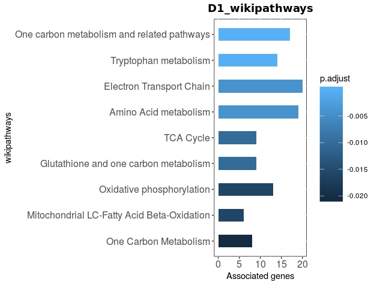

```r
Quickbar(X = Data@metadata$sigwiki[[1]], Y = Data@metadata$sigwiki[1])
```

# 10 References

1. Denise N Slenter et al. “WikiPathways: a multifaceted pathway database bridging metabolomics to other omics research”. In: Nucleic acids research 46.D1 (2017), pp. D661–D667.
2. Guangchuang Yu et al. “clusterProfiler: an R package for comparing bi- ological themes among gene clusters”. In: Omics: a journal of integrative biology 16.5 (2012), pp. 284–287.
3. Guangchuang Yu et al. “DOSE: an R/Bioconductor package for disease ontology semantic and enrichment analysis”. In: Bioinformatics 31.4 (2014), pp. 608–609.
4. Damian Smedley et al. “BioMart–biological queries made easy”. In: BMC genomics 10.1 (2009), p. 22.
5. Julia A Gustavsen et al. “RCy3: Network biology using Cytoscape from within R”. In: F1000Research 8 (2019).
6. Lokesh Kumar and Matthias E Futschik. “Mfuzz: a software package for soft clustering of microarray data”. In: Bioinformation 2.1 (2007), p. 5.
7. Maintainer Gabor Csardi. “Package igraph”. In: Last accessed 3.09 (2013), p. 2013.
8. Vikram Agarwal et al. “Predicting effective microRNA target sites in mammalian mRNAs”. In: elife 4 (2015), e05005.
9. Nathan Wong and Xiaowei Wang. “miRDB: an online resource for mi- croRNA target prediction and functional annotations”. In: Nucleic acids research 43.D1 (2014), pp. D146–D152.
10. Chih-Hung Chou et al. “miRTarBase update 2018: a resource for exper- imentally validated microRNA-target interactions”. In: Nucleic acids re- search 46.D1 (2017), pp. D296–D302.
11. Michael E Smoot et al. “Cytoscape 2.8: new features for data integration and network visualization”. In: Bioinformatics 27.3 (2010), pp. 431–432.
12. Martijn P van Iersel et al. “Presenting and exploring biological pathways with PathVisio”. In: BMC bioinformatics 9.1 (2008), p. 399.
13. Alexander R Pico et al. “WikiPathways: pathway editing for the people”. In: PLoS biology 6.7 (2008), e184.
14. Hadley Wickham et al. “dplyr: a grammar of data manipulation, 2013”. In: URL https://github. com/hadley/dplyr. version 0.1.[p 1] (2017).
15. Gregory R Warnes, Ben Bolker, and Thomas Lumley. “gtools: Various R programming tools”. In: R package version 3.1 (2014).
16. Hadley Wickham and Lionel Henry. “Tidyr: Easily tidy data withspread ()andgather ()functions”. In: R package version 0.6 1 (2017).
17. Hadley Wickham. “stringr: Make it easier to work with strings”. In: R package version 0.6 2 (2012), pp. 96–7.
18. Hadley Wickham. “The tidyverse”. In: R package ver. 1.1 1 (2017).
19. Hadley Wickham. ggplot2: elegant graphics for data analysis. Springer 2016.
20. Carlson M (2019). org.Hs.eg.db: Genome wide annotation for Human. R package version 3.8.2.
21. Carlson M (2019). org.Mmu.eg.db: Genome wide annotation for Rhesus. R package version 3.8.2.
22. Claus Thorn Ekstrom. R Primer. Chapman and Hall/CRC, 2019.
23. Ramos M, Schiffer L, Re A, Azhar R, Basunia A, Cabrera CR, Chan T, Chapman P, Davis S, Gomez-Cabrero D, Culhane AC, Haibe-Kains B, Hansen K, Kodali H, Louis MS, Mer AS, Reister M, Morgan M, Carey V, Waldron L (2017). “ Software For The Integration Of Multi-Omics Experiments In Bioconductor.” Cancer Research, 77(21); e39-42.
24. Florin L Craciun et al. “RNA sequencing identifies novel translational biomarkers of kidney fibrosis”. In: Journal of the American Society of Nephrology 27.6 (2016), pp. 1702–1713.
25. Kathryn L Pellegrini et al. “Application of small RNA sequencing to iden- tify microRNAs in acute kidney injury and fibrosis”. In: Toxicology and applied pharmacology 312 (2016), pp. 42–52.
26. Matthias E Futschik and Lokesh Kumar. “Introduction to Mfuzz package and its graphical user interface”. In: (2013).
27. Carme Camps et al. “Integrated analysis of microRNA and mRNA expres- sion and association with HIF binding reveals the complexity of microRNA expression regulation under hypoxia”. In: Molecular cancer 13.1 (2014), p. 28.
28. Maria Warnefors et al. “Conserved microRNA editing in mammalian evo- lution, development and disease”. In: Genome biology 15.6 (2014), R83.